# CSC1001 Tutorial 7

# Tutorial Notes

## By Kaiyan Zheng

kaiyanzheng@link.cuhk.edu.cn

# Introduction to Dictionaries in Python

In this lesson, we will explore the concept of dictionaries in Python, which are a powerful data structure used to store key-value pairs. Dictionaries are essential for various applications, such as storing data, settings, and more.

## What is a Dictionary?

A dictionary in Python is an unordered collection of data in a key-value pair format. Each key is associated with a specific value. Dictionaries are enclosed in curly braces `{}` and are often used when data needs to be stored with a unique identifier (key).

### Creating Dictionaries

You can create dictionaries in Python using the following syntax:

```
my_dict = {'key1': 'value1', 'key2': 'value2', ...}
```

Dictionaries can contain keys of different data types, such as strings, numbers, and even tuples.

Let's look at some examples:

```
dict1 = {'a': 1, 'b': 20}
dict2 = {1: 1, 2: 20}
tup1 = (1, 2)
tup2 = ('abc', 'xyz')
dict3 = {tup1: 1, tup2: 20}
```

### Accessing Dictionary Elements

You can access the values associated with specific keys in a dictionary using the key itself:

```
print(dict1['a'])  # Outputs: 1
print(dict2[1])    # Outputs: 1
```

### String Manipulation

We can use string manipulation methods to clean and process text data. Here, we'll explore the strip() function, which removes leading and trailing characters or whitespace from a string.

Example:

```
str1 = '  abc   abc  '
str2 = ' abc    abc '
str3 = '#  #abc   abc  '

print(str1.strip())      # Removes leading and trailing whitespace
print(str2.strip())      # Removes leading and trailing whitespace
print(str3.strip('#'))   # Removes leading and trailing '#'
```

Random Number Generation

Random numbers are often used in various applications, such as simulations, games, and more. Python provides the random module to generate random numbers.

Generating Random Numbers `random.random()`: Generates a random float between 0 and 1 (exclusive). `random.randint(a, b)`: Generates a random integer between `a` and `b`, inclusive. `random.uniform(a, b)`: Generates a random float between `a` and `b`, inclusive.

```
import random

a = random.random()
b = random.randint(0, 10)
c = random.uniform(0, 10)

print(a)  # Random float between 0 and 1
print(b)  # Random integer between 0 and 10
print(c)  # Random float between 0 and 10
```

## Q1: Count occurences

## Write a program that reads some integers between 1 and 100 and counts the occurrences of each.

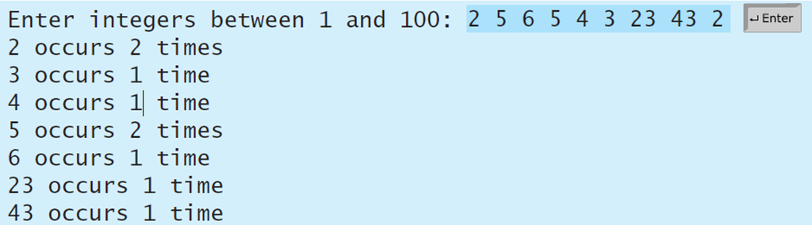

## Note that if a number occurs more than one time, the plural word “times” is used in the output.

```python
# Prompt the user to input a line of integers separated by spaces
integerLine = input("Enter several integers in the interval [1, 9] (separated by space):\n")

# Split the input line into a list of individual integer values
integerList = integerLine.split()

# Create an empty dictionary to store the count of each integer
countDict = dict()

# Iterate through the list of integers and count the occurrences of each integer
for integer in integerList:
    countDict[integer] = countDict.get(integer, 0) + 1

# Iterate through the dictionary to print the count of each integer
for key, value in countDict.items():
    if value > 1:
        print("%s occurs %d times." % (key, value))
    else:
        print("%s occurs %d time." % (key, value))
```

```
Enter several integers in the interval [1, 9] (separated by space):
1 5 5 6 8 9 9 9
1 occurs 1 time.
5 occurs 2 times.
6 occurs 1 time.
8 occurs 1 time.
9 occurs 3 times.
```

Explanation:

1. **Prompt User for Input**: The program starts by prompting the user to enter a line of integers.
2. **Store User Input**: `integerLine` stores the user's input as a string.
3. **Split Input into List**: `integerList` is created by splitting `integerLine` into a list of individual integer values, using the `split()` method, which splits the string based on spaces.
4. **Create a Count Dictionary**: `countDict` is an empty dictionary that will be used to store the count of each integer.
5. **Count Occurrences**: The code then loops through `integerList`, and for each integer, it updates the count in `countDict`. It uses the `get()` method to safely access the count for a given integer. If the integer is not in the dictionary yet, it initializes the count to 0 and then increments it by 1.
6. **Print Occurrences**: Finally, the code iterates through `countDict` and prints the count of each integer. It checks whether the count is greater than 1 to correctly print "times" for counts greater than 1 and "time" for counts equal to 1.

This program effectively counts the occurrences of integers in the input and provides a clear output with the count for each unique integer.

## Q2: Display distinct numbers

## Write a program that reads in numbers separated by a space in one line and displays distinct numbers (i.e., if a number appears multiple times, it is displayed only once).

## Hint: Read all the numbers and store them in list1. Create a new list list2. Add a number in list1 and list2. If the number is already in the list, ignore it.

Here is the sample run of the program:

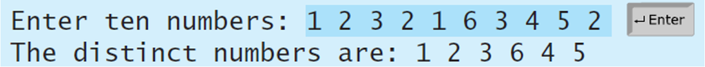

```python
# Prompt the user to enter ten numbers separated by spaces
numberLine = input("Enter ten numbers (separated by space):\n")

# Split the input line into a list of individual number strings
numberList = numberLine.split()

# Create an empty list to store distinct numbers
distinctNumbers = []

# Iterate through the list of numbers to find distinct numbers
for number in numberList:
    if number not in distinctNumbers:
        distinctNumbers.append(number)

# Print the distinct numbers
print("The distinct numbers are:", end='')
for number in distinctNumbers:
    print(number, end=' ')
```

```
Enter ten numbers (separated by space):
2020 2020 2020 2021 2023 2022 2024 2022 2025 2026
The distinct numbers are:2020 2021 2023 2022 2024 2025 2026
```

1. **Prompt User for Input**: The program starts by prompting the user to enter ten numbers separated by spaces.
2. **Store User Input**: `numberLine` stores the user's input as a string.
3. **Split Input into List**: `numberList` is created by splitting `numberLine` into a list of individual number strings, using the `split()` method, which splits the string based on spaces.
4. **Create a List for Distinct Numbers**: `distinctNumbers` is an empty list that will be used to store distinct numbers.
5. **Find Distinct Numbers**: The code then iterates through `numberList` and checks if each number is not already in the `distinctNumbers` list. If the number is not in the list, it is added to `distinctNumbers`, ensuring that only distinct numbers are included.
6. **Print Distinct Numbers**: Finally, the code prints the distinct numbers by iterating through `distinctNumbers`. It uses `end=''` to prevent the default newline character, ensuring that the numbers are printed on the same line.

This program effectively finds and prints the distinct numbers entered by the user.

## Q3: Compute mean and deviation

## Compute the standard deviation of n numbers:

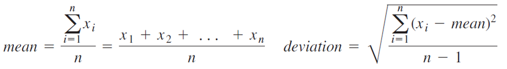

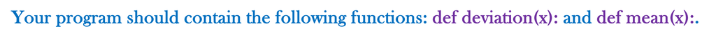

## Write a test program that prompts the user to enter a list of numbers and displays the mean and standard deviation, as shown in the following sample run:

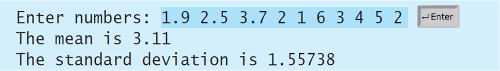

```python
# Define a function to calculate the mean of a list of numbers
def mean(x):
    return sum(x) / len(x)

# Define a function to calculate the standard deviation of a list of numbers
def deviation(x):
    # Calculate the squared deviations from the mean and normalize by (n-1)
    deviationList = [(xi - mean(x)) ** 2 / (len(x) - 1) for xi in x]
    # Calculate the standard deviation by taking the square root of the sum of deviations
    deviation = sum(deviationList) ** 0.5
    return deviation

# Define the main function to interact with the user
def main():
    # Prompt the user to enter numbers separated by spaces
    numberLine = input("Enter numbers whose mean and deviation you want to calculate (separated by space):\n")
    numberList = numberLine.split()

    # Convert the input strings to a list of numbers using the eval() function
    numberList = [eval(x) for x in numberList]

    # Calculate and print the mean and standard deviation
    print("The mean is", mean(numberList))
    print("The standard deviation is", deviation(numberList))

# Call the main function to start the program
main()
```

```
Enter numbers whose mean and deviation you want to calculate (separated by space):
97 90 86 48 67 87 56 89 72 68 99 82
The mean is 78.41666666666667
The standard deviation is 16.144001606751278
```

1. **Define Mean Function**: The `mean(x)` function calculates the mean of a list of numbers by dividing the sum of the numbers by the count of numbers.
2. **Define Deviation Function**: The `deviation(x)` function calculates the standard deviation of a list of numbers. It first calculates the squared deviations from the mean, normalizing by `(n-1)`. Then, it calculates the standard deviation by taking the square root of the sum of squared deviations.
3. **Main Function**: The `main()` function is the core of the program. It prompts the user to enter numbers separated by spaces. It then converts the input strings into a list of numbers using the `eval()` function. Finally, it calculates and prints the mean and standard deviation of the entered numbers.
4. **Start the Program**: The program is initiated by calling the `main()` function.

This program allows the user to input a list of numbers, calculates the mean and standard deviation, and provides the results.

## Q4: Test sorted list

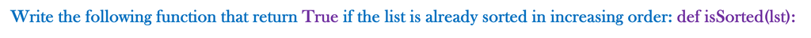

## Write a test program that prompts the user to enter a list and displays whether the list is sorted or not. Here is a sample run:

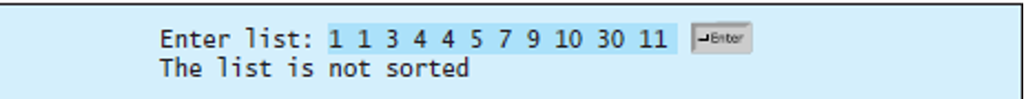

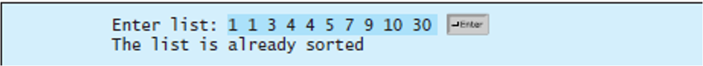

```python
# Define a function to check if a list is sorted in ascending order
def isSorted(lst):
    for i in range(len(lst) - 1):
        if lst[i] > lst[i + 1]:
            return False
    return True

# Define the main function to interact with the user
def main():
    # Prompt the user to enter elements in a list separated by space
    lst = input("Enter elements in a list separated by space:\n").split()

    # Convert the input strings to a list of numbers using the eval() function
    lst = [eval(x) for x in lst]

    # Check if the list is sorted and print the result
    if isSorted(lst):
        print("The list is already sorted.")
    else:
        print("The list is not sorted.")

# Call the main function to start the program
main()
```

```
Enter elements in a list separated by space:
1 4 5 8 9 10 21 24 56 88 99 100
The list is already sorted.
```

1. **Define isSorted Function**: The `isSorted(lst)` function checks if a list is sorted in ascending order. It iterates through the elements in the list and compares each element with the next. If it finds an element greater than the next one, it returns `False`, indicating that the list is not sorted. If it completes the loop without finding such an element, it returns `True`, indicating that the list is sorted.
2. **Main Function**: The `main()` function is the core of the program. It prompts the user to enter elements in a list separated by spaces. It then converts the input strings into a list of numbers using the `eval()` function. Next, it calls the `isSorted()` function to check if the list is sorted and prints the result.
3. **Start the Program**: The program is initiated by calling the `main()` function.

This program allows the user to input a list of elements, and it checks whether the list is sorted in ascending order or not. It provides feedback based on the result.

## Q5: Word recitation

### The file `Dictionary.txt` stores some words along with their meanings in English, using colon “:” to separate. Write a program to randomly select an English word from the file and allow users to guess it by looking at the description of it on the screen. The program will give you feedback whether your guess is correct or not. If wrong, it will tell you the correct answer. Words in the file won’t appear twice and after finishing guessing all words in the file, the program will tell you how many words you guess correctly.

```python
import random

file=open("Dictionary.txt",'r') # Make sure Dictionary.txt is put in the same folder
words={}
# Parse the lines of the file to populate the dictionary
for line in file.readlines():
    word = line.split(':')
    words[word[1].strip()] = word[0].strip()

# Create a list of keys from the dictionary
k = list(words.keys())
total = len(k)  # Get the total number of words in the dictionary

# Initialize a variable to count correct guesses
count = 0

# Continue the game until there are words left in the list
while k:
    # Generate a random index to select a word to guess
    i = random.randint(0, len(k) - 1)

    # Print the current word being guessed and the progress
    print('(%d/%d)' % (total - len(k) + 1, total), k[i])
    answer = input('Please guess the word: ')

    # Check if the answer is correct and provide feedback
    if answer == words[k[i]]:
        print("√√√\nYour answer is correct!\n")
        count += 1
    else:
        print("×××\nThe correct answer should be \"%s\".\n"%words[k[i]])
##  Romove the word that you have just guessed
    k.remove(k[i])
print('Finished!You have correctly guess %d out of %d words!'%(count,total))

file.close()
```

```
(1/27) an examination administered in the middle of an academic term
Please guess the word: midterm
√√√
Your answer is correct!

(2/27) the time period between dawn and noon
Please guess the word: morning
√√√
Your answer is correct!

(3/27) someone who is a member of the faculty at a college or university
Please guess the word: professor
√√√
Your answer is correct!

(4/27) the period during which something is functional (as between birth and death)
Please guess the word: teenager
×××
The correct answer should be "life".

(5/27) enjoying or showing or marked by joy or pleasure or good fortune
```

This program creates an interactive word guessing game where the user tries to match words with their meanings from a dictionary.